# Ken-Behrenia House Price

Mean Squared Error for this model is 1.0323.

```r
library(pls)

set.seed(1)

pcr.model <- pcr(price ~ cond + year + built + lat + lon + sq.m.h + sq.m.block + sq.m.pool + reno + as.numeric(bedrooms) + as.numeric(bathrooms) + environ, data = train, scale = TRUE, validation = "CV")

summary(pcr.model)
```

```
## Data:    X dimension: 30000 34
##  Y dimension: 30000 1
## Fit method: svdpc
## Number of components considered: 34
##
## VALIDATION: RMSEP
## Cross-validated using 10 random segments.
##        (Intercept)  1 comps  2 comps  3 comps  4 comps  5 comps  6 comps
## CV           1.139     1.07    1.046   0.9917   0.9361   0.9207   0.9175
## adjCV        1.139     1.07    1.046   0.9916   0.9359   0.9207   0.9175
##        7 comps  8 comps  9 comps  10 comps  11 comps  12 comps  13 comps
## CV      0.9159   0.9144   0.9143    0.9109    0.9101    0.9091    0.9079
## adjCV   0.9158   0.9143   0.9144    0.9108    0.9105    0.9095    0.9088
##        14 comps  15 comps  16 comps  17 comps  18 comps  19 comps  20 comps
## CV       0.9024     0.900    0.8977    0.8958    0.8941    0.8933    0.8782
## adjCV    0.9023     0.901    0.8977    0.8956    0.8938    0.8933    0.8780
##        21 comps  22 comps  23 comps  24 comps  25 comps  26 comps  27 comps
## CV       0.8762    0.8755    0.8701    0.8696    0.8694    0.8522    0.8519
## adjCV    0.8761    0.8756    0.8701    0.8695    0.8694    0.8522    0.8519
##        28 comps  29 comps  30 comps  31 comps  32 comps  33 comps  34 comps
## CV       0.8419    0.8079    0.7625    0.7587    0.7223    0.6264    0.6255
## adjCV    0.8419    0.8079    0.7624    0.7589    0.7223    0.6264    0.6254
##
## TRAINING: % variance explained
##        1 comps  2 comps  3 comps  4 comps  5 comps  6 comps  7 comps  8 comps
## X        8.309    13.57    18.61    22.83    26.93    30.68    34.20    37.58
## price   11.738    15.66    24.25    32.52    34.70    35.16    35.39    35.59
##        9 comps  10 comps  11 comps  12 comps  13 comps  14 comps  15 comps
## X        40.94     44.25     47.51     50.75     53.98     57.19     60.37
## price    35.61     36.14     36.20     36.36     36.43     37.38     37.58
##        16 comps  17 comps  18 comps  19 comps  20 comps  21 comps  22 comps
## X         63.54     66.67     69.79     72.89     75.91     78.89     81.81
## price     38.02     38.30     38.60     38.63     40.72     40.97     41.04
##        23 comps  24 comps  25 comps  26 comps  27 comps  28 comps  29 comps
## X         84.66     87.34     89.98     92.50     94.35     96.09     97.63
## price     41.80     41.88     41.91     44.16     44.21     45.52     49.83
##        30 comps  31 comps  32 comps  33 comps  34 comps
## X         98.41     98.91     99.39     99.73    100.00
## price     55.33     55.76     59.92     69.86     69.95
```

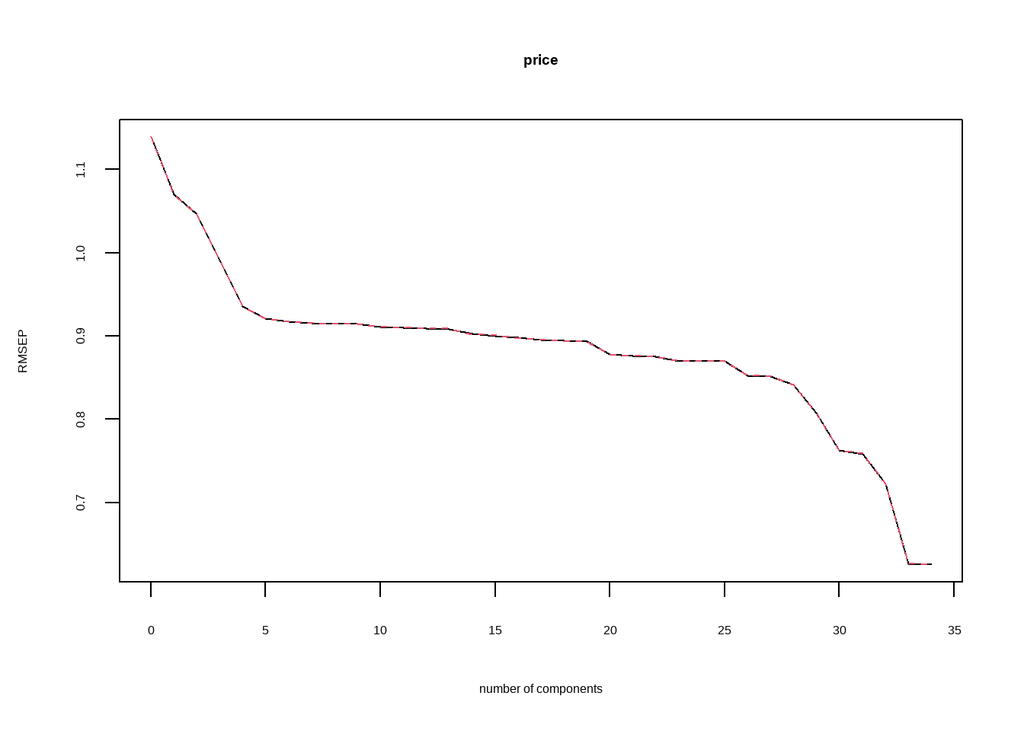

```r
#visualize cross-validation plots
validationplot(pcr.model)
```

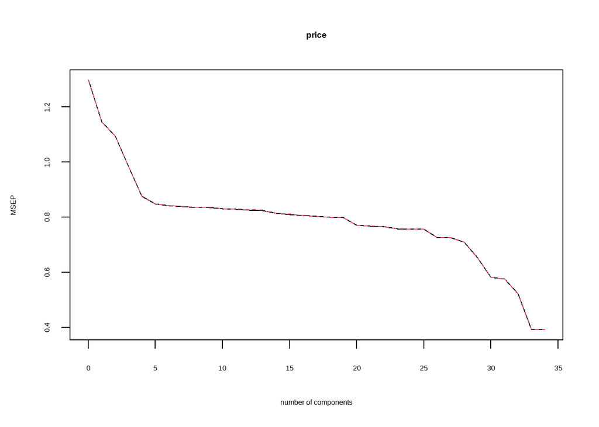

```r
validationplot(pcr.model, val.type="MSEP")
```

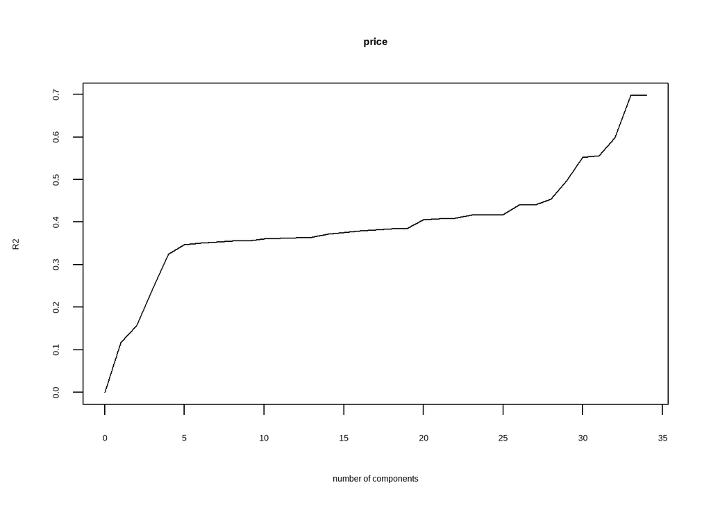

```r
validationplot(pcr.model, val.type="R2")
```

```r
#define training and testing sets
train.pcr <- train[1:24000, c("cond", "year", "built", "lat", "lon", "sq.m.h","sq.m.block","sq.m.pool","reno","bedrooms","bathrooms","environ")]

y.test.pcr <- train[24001:nrow(train), c("price")]

test.pcr <- train[24001:nrow(train), c("cond", "year", "built", "lat", "lon", "sq.m.h","sq.m.block","sq.m.pool","reno","bedrooms","bathrooms","environ")]

#use model to make predictions on a test set
pcr.model.pred <- pcr(price ~ cond + year + built + lat + lon + sq.m.h + sq.m.block + sq.m.pool + reno + as.numeric(bedrooms) + as.numeric(bathrooms) + environ, data = train, scale=TRUE, validation="CV")

pcr.pred <- predict(pcr.model.pred, test.pcr, ncomp=2)

#calculate MSE
mse.pcr <- mean((pcr.pred - y.test.pcr)^2)
mse.pcr
```

```
## [1] 1.032316
```

## Best Predictive Model for Modelling Component 1

My Kaggle public name is YuHeng26.

The best predictive model for Modelling Component 1 is the second model: Linear Regression of Generalized Linear Model. To justify my point, the criterion for the predictions is Mean Squared Error, the second model provides the lowest Mean Squared Error of 0.3673. This means that the prediction errors is the lowest, providing a better predictive model.

```r
test.price <- test
glm.model.pred.value <- predict(model, newdata = test)
test.price$price <- glm.model.pred.value


glm.model.sub <- subset(test.price, select = c(id, price))
write.csv(glm.model.sub, "C:\\Users\\Yu Heng\\Documents\\Archive\\ANU\\2022 SEM 1\\STAT3040\\Assignment 3\\glm_predicted_sent.csv", row.names = FALSE)
```

## 4. Modelling Component 2

First model: Multiple regression with backward selection method

```r
n <- nrow(train)
K <- 10
train.sample <- sample(1:n, n/10)


set.seed(1)

fold <- sample(rep(1:K , each=n/K))

data.train <- train[fold != K,]
data.test <- train[fold == K,]

full.model.2 <- lm(as.numeric(sent) ~., data = train)

step.model.2 <- stepAIC(full.model.2, direction = "backward", trace = FALSE)

anova(step.model.2)
```

|  | Df | Sum Sq | Mean Sq | F value | Pr(>F) |
| --- | --- | --- | --- | --- | --- |
| price | 1 | 1181.395036 | 1181.3950359 | 9741.077873 | 0.000000e+00 |
| year | 11 | 343.568494 | 31.2334994 | 257.532782 | 0.000000e+00 |
| built | 9 | 133.144255 | 14.7938061 | 121.980890 | 2.219298e-226 |
| lat | 1 | 48.606177 | 48.6061774 | 400.777508 | 1.418280e-88 |
| lon | 1 | 93.627581 | 93.6275813 | 771.997116 | 8.919889e-168 |
| sq.m.h | 1 | 19.402560 | 19.4025599 | 159.981920 | 1.416496e-36 |
| sq.m.block | 1 | 2.113828 | 2.1138285 | 17.429367 | 2.990254e-05 |
| sq.m.pool | 1 | 60.275306 | 60.2753056 | 496.994171 | 3.321108e-109 |
| reno | 1 | 1.092363 | 1.0923626 | 9.006969 | 2.691735e-03 |
| bedrooms | 11 | 41.249564 | 3.7499604 | 30.919934 | 7.396172e-66 |

[output cut: 3 more lines]

```r
mr2 <- lm(as.numeric(sent) ~ year + built + lat + lon + sq.m.h + sq.m.block + sq.m.pool + reno + bedrooms + bathrooms + environ, data = train)
anova(mr2)
```

|  | Df | Sum Sq | Mean Sq | F value | Pr(>F) |
| --- | --- | --- | --- | --- | --- |
| year | 11 | 10.489682 | 0.9536075 | 6.764744 | 1.821076e-11 |
| built | 9 | 78.726043 | 8.7473381 | 62.052267 | 2.086445e-113 |
| lat | 1 | 33.339605 | 33.3396048 | 236.506011 | 3.630818e-53 |
| lon | 1 | 47.499300 | 47.4993004 | 336.952707 | 7.577184e-75 |
| sq.m.h | 1 | 1003.398029 | 1003.3980288 | 7117.950774 | 0.000000e+00 |
| sq.m.block | 1 | 7.946674 | 7.9466738 | 56.372477 | 6.163130e-14 |
| sq.m.pool | 1 | 49.871638 | 49.8716384 | 353.781707 | 1.804668e-78 |
| reno | 1 | 2.092730 | 2.0927304 | 14.845506 | 1.169289e-04 |
| bedrooms | 11 | 76.550100 | 6.9591000 | 49.366781 | 2.205824e-108 |
| bathrooms | 9 | 54.506394 | 6.0562660 | 42.962217 | 3.164327e-77 |

[output cut: 2 more lines]

```r
p.hat.lm.2 <- predict(mr2, data.train[-train.sample,], type="response")
y.hat.lm.2 <- rep(0, n/10)
y.hat.lm.2[p.hat.lm.2 >= 0.5] <- 1
y.lm.2 <- (data.train[-train.sample,]$sent == "1")*1

table.lm.2 <- table(y.lm.2,y.hat.lm.2)
accuracy_Test.lm.2 <- sum(diag(table.lm.2)) / sum(table.lm.2)

accuracy_Test.lm.2
```

```
## [1] 0.7502368
```

Second model: Logistic Regression of Generalized Linear Model using k-fold cross validation with forward selection method based on the value of AIC.

```r
n <- nrow(train)
train.sample <- sample(1:n, n/10)

# K fold
K <- 10

##
set.seed(1)
fold <- sample(rep(1:K , each=n/K))

##
for (k in 1:K) {

  data.train <- train[fold != k,]
  data.test <- train[fold == k,]

  glm.model.2 <- glm(sent ~ cond + built + lat + lon + sq.m.h + sq.m.block + sq.m.pool + reno + as.numeric(bedrooms) + as.numeric(bathrooms) + environ, family = binomial, data = data.train)
  pred.test.glm.2 <- predict(glm.model.2, newdata = data.test)
  mse.out2 <- mean((as.numeric(data.test$sent) - pred.test.glm.2)^2, na.rm = TRUE)

}

p.hat.glm.2 <- predict(glm.model.2, data.train[-train.sample,], type="response")
y.hat.glm.2 <- rep(0, n/10)
y.hat.glm.2[p.hat.glm.2 >= 0.5] <- 1
y.glm.2 <- (data.train[-train.sample,]$sent == "1")*1

## Confusion matrix
table.glm.2 <- table(y.glm.2,y.hat.glm.2)
accuracy_Test.glm.2 <- sum(diag(table.glm.2)) / sum(table.glm.2)
accuracy_Test.glm.2
```

```
## [1] 0.7436114
```

Third Model: Linear Discriminant Analysisn of 10-fold cross validation with backward elimination method

Using backward elimination method for this LDA model, the best predictors are cond, year, built, lat, lon, sq.m.h, sq.m.pool, reno, bedrooms, bathrooms and environ.

95% confidence interval for somewhat satisfied or not satisfied: [0.7471,0.7569] 95% confidence interval for very satisfied: [0.2431,0.2529]

```r
library(MASS)
library(caret)
library(pROC)

##
set.seed(1)
fold <- sample(rep(1:K , each=n/K))

data.train.lda <- train[fold != k,]
data.test.lda <- train[fold == k,]

lda.model <- lda(sent ~ cond + year + built + lat + lon + sq.m.h + sq.m.pool + reno + bedrooms + bathrooms + environ, data = train)

predictions <- predict(lda.model, data.test.lda)
predictions.probs <- predictions$posterior[,2]
predicted.classes <- predictions$class
observed.classes <- data.test.lda$sent

accuracy <- mean(observed.classes == predicted.classes)
accuracy
```

```
## [1] 0.8133333
```

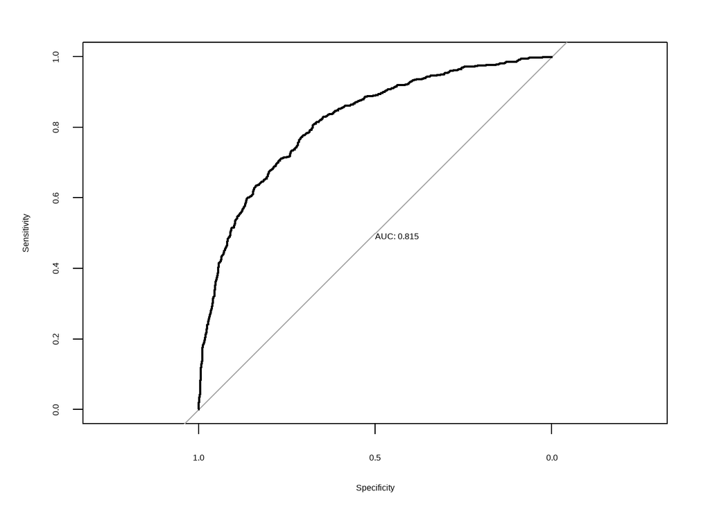

```r
# Compute roc
res.roc <- roc(observed.classes, predictions.probs)
plot.roc(res.roc, print.auc = TRUE)
```

```r
# 95% confidence interval
sent.size <- 30000
p.0 <- 22561/30000
p.1 <- 7439/30000

margin.0 <- qnorm(0.975)*sqrt(p.0*(1-p.0)/sent.size)
margin.1 <- qnorm(0.975)*sqrt(p.1*(1-p.1)/sent.size)

lowerinterval.0 <- p.0 - margin.0
lowerinterval.1 <- p.1 - margin.1

upperinterval.0 <- p.0 + margin.0
upperinterval.1 <- p.1 + margin.1
```

Fourth Model: Quadratic Discriminant Analysis of 10 fold cross validation with backward elimination method

Using backward elimination method for this model, the best predictors are cond, year, lat, sq.m.h, sq.m.pool, reno, bedrooms and bathrooms.

Correct classification rate for this model is 0.7943 with AUC of 0.758.

```r
for (k in 1:K) {

  data.train.qda <- train[fold != k,]
  data.test.qda <- train[fold == k,]

  qda.model <- qda(sent ~ cond + year + lat + sq.m.h + sq.m.pool + reno + as.numeric(bedrooms) + as.numeric(bathrooms), data = data.train.qda)
  pred.test.qda <- predict(qda.model, newdata = data.test.qda)
  pred.prob.qda <- pred.test.qda$posterior[,2]
  pred.class.qda <- pred.test.qda$class
  observed.classes.qda <- data.test.qda$sent

  accuracy.qda <- mean(observed.classes.qda == pred.class.qda)

}
accuracy.qda
```

```
## [1] 0.7943333
```

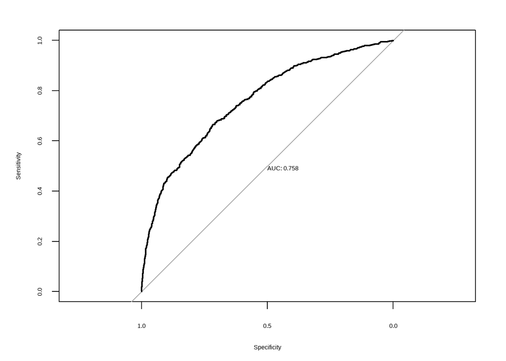

```r
# Compute roc
res.roc <- roc(observed.classes.qda, pred.prob.qda)
plot.roc(res.roc, print.auc = TRUE)
```

Fifth Model: Decision Tree

Splitting the data to 80/20, with 80 percent of the data serves to train the model, and 20 percent to make predictions.

Changing all the parameters in the control, I find the best accuracy for this model is 0.8067.

Correct classification rate for this model is 0.8067.

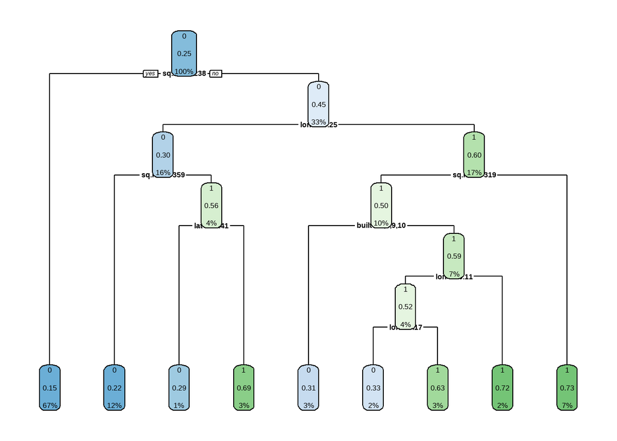

```r
library(rpart)
library(rpart.plot)
library(caret)

n <- nrow(train)

new.train <- subset(train, select = -c(price))

total_row <- 0.8 * n
train_sample <- 1:total_row
data.train.tree <- new.train[train_sample, ]
data.test.tree <- new.train[-train_sample, ]

tree.fit <- rpart(sent~., data = data.train.tree, method = 'class')
rpart.plot(tree.fit, extra = 106)
```

```r
accuracy_tune <- function(fit) {
    predict_unseen <- predict(tree.fit, data.test.tree, type = 'class')
    table_mat <- table(data.test.tree$sent, predict_unseen)
    accuracy_Test <- sum(diag(table_mat)) / sum(table_mat)
    accuracy_Test
}

control <- rpart.control(minsplit = 20,
    minbucket = round(20 / 3),
    maxdepth = 30,
    cp = 0)
tune_fit <- rpart(sent~., data = data.train.tree, method = 'class', control = control)
accuracy_tune(tune_fit)
```

```
## [1] 0.8066667
```

```r
# Predict using the tree model on the test data
predictions <- predict(tree.fit, newdata = data.test.tree, type = "class")

# Create the confusion matrix
confusion_matrix <- confusionMatrix(predictions, data.test.tree$sent)
print(confusion_matrix)
```

```
## Confusion Matrix and Statistics
##
##           Reference
## Prediction    0    1
##          0 4266  904
##          1  256  574
##
##                Accuracy : 0.8067
##                  95% CI : (0.7964, 0.8166)
##     No Information Rate : 0.7537
##     P-Value [Acc > NIR] : < 2.2e-16
##
##                   Kappa : 0.3892
##
##  Mcnemar's Test P-Value : < 2.2e-16
##
##             Sensitivity : 0.9434
##             Specificity : 0.3884
##          Pos Pred Value : 0.8251
##          Neg Pred Value : 0.6916
##              Prevalence : 0.7537
##          Detection Rate : 0.7110
##    Detection Prevalence : 0.8617
##       Balanced Accuracy : 0.6659
##
##        'Positive' Class : 0
##
```

## Best Predictive Model for Modelling Component 2

```r
test.sent <- test

lda.model.pred.value <- predict(lda.model, newdata = test)
prediction.lda.values <- lda.model.pred.value$x

test_pred_lda <- factor(ifelse(prediction.lda.values > 0.5, "True", "False"))

test.sent$sent <- test_pred_lda

test.sent$sent <- recode_factor(test.sent$sent, 'False' = '0', 'True' = '1')
test.sent$sent <- recode_factor(test.sent$sent, '0' = 0,  '1' = 1)


lda.model.sub <- subset(test.sent, select = c(id, sent))
write.csv(lda.model.sub,"C:\\Users\\Yu Heng\\Documents\\Archive\\ANU\\2022 SEM 1\\STAT3040\\Assignment 3\\lda_predicted_sent.csv",row.names = FALSE)
```

## Discussions and Limitations

For this report, there are limitations when using single imputation. Single imputation value is treated as the true value and do not report the uncertainty towards the prediction of the missing values. To fill in the missing values of this dataset, multiple imputation method should be used as it is more advantageous. To justify my point, multiple imputation considers the variance estimation and interval estimation for the interested parameters. As multiple imputation method can be tedious, with the lack of great knowledge towards the multiple imputation method, single imputation was used in this report.

## Conclusions

In conclusion, for both modelling components in this report, we find sq.m.h and bathrooms play an influential role on the predicted results. Several factors can determine the price of the house and the satisfaction score.